MARKET DATA LAB · REPRODUCIBLE RESEARCH

# SNDK Stock Data: EDA & 2026 Forecast

### From raw Yahoo Finance prices to honest forecast evaluation

Author: **Muhammad Ibrahim Shahrukh**

403 observations · 2025-02-13 → 2026-09-22 · Forecast origin: 2026-09-22

### What will you learn?

1. Validate and understand daily OHLCV data.
2. Explore trend, drawdowns, returns, volume, volatility and calendar patterns.
3. Compare simple baselines and machine learning with chronological validation.
4. Forecast the remaining scheduled trading sessions of 2026 and examine uncertainty.

**Research question:** Can historical closing prices improve a multi-session price forecast over simply carrying forward the latest close?

> This is an educational analysis of the supplied snapshot, not independently verified live quotes or investment advice. Historical records, model predictions and simulated uncertainty are kept separate. No model is universally best, and notebook rankings cannot be guaranteed.

## 01 · Setup & reproducibility

Offline data; explicit configuration; interactive charts plus static fallbacks.

Run all cells from top to bottom. On Kaggle, attach the clean CSV as an input dataset. The loader finds it automatically; if several copies exist, set `DATA_PATH`. This notebook needs no market-data API or internet connection once dependencies are installed. `requirements.txt` lists the packages. Plotly creates interactive panels; Matplotlib panels remain visible in static viewers such as GitHub. Trust a downloaded notebook to enable interactive HTML.

```python
from pathlib import Path
import json, hashlib, platform, importlib.metadata, warnings
import numpy as np
import pandas as pd
import matplotlib.pyplot as plt
import seaborn as sns
import plotly.express as px
import plotly.graph_objects as go
import plotly.io as pio
from plotly.subplots import make_subplots
from IPython.display import display, HTML, Markdown
from sklearn.pipeline import make_pipeline
from sklearn.preprocessing import StandardScaler
from sklearn.linear_model import Ridge
from sklearn.ensemble import RandomForestRegressor, ExtraTreesRegressor, HistGradientBoostingRegressor
from sklearn.metrics import mean_absolute_error, mean_squared_error, r2_score
from statsmodels.tsa.stattools import adfuller
from xgboost import XGBRegressor
from catboost import CatBoostRegressor

SEED = 42
np.random.seed(SEED)
DATA_PATH = None  # Optional: Path('/kaggle/input/your-dataset/sndk_daily_clean.csv')
OUT = Path('/kaggle/working/sndk_outputs') if Path('/kaggle').exists() else Path('outputs')
OUT.mkdir(parents=True, exist_ok=True)
pio.templates.default = 'plotly_dark'
pio.renderers.default = 'plotly_mimetype+notebook'
COLORS = ['#22d3ee','#a78bfa','#34d399','#fb7185','#fbbf24','#60a5fa','#f472b6','#a3e635']
px.defaults.color_discrete_sequence = COLORS
plt.style.use('seaborn-v0_8-darkgrid')
sns.set_palette(COLORS)

def show(fig, title, height=520):
    fig.update_layout(title=title, height=height, paper_bgcolor='#111b32',
                      plot_bgcolor='#16223c', font=dict(family='Arial',size=13),
                      margin=dict(t=80,l=65,r=35,b=60))
    fig.show(config={'displaylogo':False, 'responsive':True})

def card(title, body, color='#2563eb'):
    display(HTML(f'<div style="border-left:6px solid {color};background:#edf4ff;color:#12213a;padding:16px;margin:14px 0;border-radius:8px"><b>{title}</b><br>{body}</div>'))

versions = {p:importlib.metadata.version(p) for p in ['numpy','pandas','scikit-learn','plotly','matplotlib','seaborn','statsmodels','xgboost','catboost']}
print('Python:',platform.python_version())
print(json.dumps(versions,indent=2))
```

```
Python: 3.12.14
{
  "numpy": "2.5.3",
  "pandas": "3.0.6",
  "scikit-learn": "1.8.0",
  "plotly": "7.1.0",
  "matplotlib": "3.11.2",
  "seaborn": "0.13.2",
  "statsmodels": "0.15.0",
  "xgboost": "3.4.1",
  "catboost": "1.2.10"
}
```

## 02 · Load, validate & explain the data

A compact, beginner-friendly table: one row per observed trading date.

```python
if DATA_PATH is None:
    candidates = [p for p in [Path('data/sndk_daily_clean.csv'),Path('sndk_daily_clean.csv')] if p.exists()]
    if not candidates and Path('/kaggle/input').exists():
        candidates = sorted(Path('/kaggle/input').rglob('sndk_daily_clean.csv'))
    if len(candidates) != 1:
        raise ValueError(f'Expected one clean CSV; found {len(candidates)}. Set DATA_PATH explicitly.')
    DATA_PATH = candidates[0]
df = pd.read_csv(DATA_PATH,parse_dates=['date'])
expected = ['date','ticker','open','high','low','close','volume']
assert df.columns.tolist() == expected
assert df.date.is_monotonic_increasing and df.date.is_unique
assert not df.isna().any().any()
assert df.ticker.eq('SNDK').all()
assert np.isfinite(df[['open','high','low','close','volume']]).all().all()
assert (df[['open','high','low','close']] > 0).all().all()
assert (df.volume >= 0).all() and (df.volume % 1 == 0).all()
assert (df.high >= df[['open','close','low']].max(axis=1)).all()
assert (df.low <= df[['open','close','high']].min(axis=1)).all()
assert (df.date.dt.dayofweek < 5).all()
assert df.date.max() <= pd.Timestamp('2026-09-24')
display(df.head().style.format({c:'{:,.4f}' for c in ['open','high','low','close']}))
display(df.describe(include='all').T)
audit = pd.DataFrame({'check':['Rows','Missing cells','Duplicate dates','Zero-volume rows','Before regular listing'],
                      'value':[len(df),int(df.isna().sum().sum()),int(df.date.duplicated().sum()),int(df.volume.eq(0).sum()),int(df.date.lt('2025-02-24').sum())]})
display(audit)
audit.to_csv(OUT/'data_quality_checks.csv',index=False)
```

|  | date | ticker | open | high | low | close | volume |
| --- | --- | --- | --- | --- | --- | --- | --- |
| 0 | 2025-02-13 00:00:00 | SNDK | 35.0600 | 44.0000 | 34.9900 | 36.0000 | 369100 |
| 1 | 2025-02-14 00:00:00 | SNDK | 37.0000 | 38.2500 | 35.5050 | 36.6500 | 242700 |
| 2 | 2025-02-18 00:00:00 | SNDK | 40.5300 | 47.1500 | 39.0000 | 47.1500 | 444500 |
| 3 | 2025-02-19 00:00:00 | SNDK | 46.5100 | 48.5000 | 45.5000 | 46.0000 | 220700 |
| 4 | 2025-02-20 00:00:00 | SNDK | 48.9800 | 49.4900 | 46.7100 | 48.2600 | 446200 |

|  | count | unique | top | freq | mean | min | 25% | 50% | 75% | max | std |
| --- | --- | --- | --- | --- | --- | --- | --- | --- | --- | --- | --- |
| date | 403 | NaN | NaN | NaN | 2025-12-02 22:19:57.022332 | 2025-02-13 00:00:00 | 2025-07-10 12:00:00 | 2025-12-02 00:00:00 | 2026-04-28 12:00:00 | 2026-09-22 00:00:00 | NaN |
| ticker | 403 | 1 | SNDK | 403 | NaN | NaN | NaN | NaN | NaN | NaN | NaN |
| open | 403.0 | NaN | NaN | NaN | 576.149241 | 29.219999 | 47.0 | 226.0 | 1043.309998 | 2293.314941 | 646.702626 |
| high | 403.0 | NaN | NaN | NaN | 599.885014 | 31.07 | 48.3225 | 237.770004 | 1086.830017 | 2354.389893 | 671.656377 |
| low | 403.0 | NaN | NaN | NaN | 553.398457 | 27.885 | 46.045 | 213.5 | 1003.535004 | 2251.284912 | 620.361382 |
| close | 403.0 | NaN | NaN | NaN | 578.331352 | 29.620001 | 46.98 | 226.960007 | 1040.049988 | 2335.0 | 647.834627 |
| volume | 403.0 | NaN | NaN | NaN | 10308864.764268 | 220700.0 | 3531950.0 | 9586700.0 | 14770700.0 | 43000900.0 | 7392904.308489 |

|  | check | value |
| --- | --- | --- |
| 0 | Rows | 403 |
| 1 | Missing cells | 0 |
| 2 | Duplicate dates | 0 |
| 3 | Zero-volume rows | 0 |
| 4 | Before regular listing | 6 |

| Column | Short description | Meaning / units |
| --- | --- | --- |
| date | Trading session date | ISO date, exchange-local date label |
| ticker | Stock ticker symbol | SNDK, Sandisk Corporation |
| open | Session opening price | USD per share, as supplied |
| high | Session highest price | USD per share, as supplied |
| low | Session lowest price | USD per share, as supplied |
| close | Session closing price | USD per share, as supplied |
| volume | Shares traded | Nonnegative integer shares |

**Provenance.** The user supplied a CSV reported to have been collected from Yahoo Finance using the unofficial `yfinance` Python package. The original download timestamp, package version, parameters, regular/extended-session settings and adjustment flag were not supplied. The two metadata rows are consistent with a multi-index yfinance export. The absence of `Adj Close` does **not** prove whether these prices are adjusted. No dividend, split or currency-conversion adjustments are applied here; no new price history is fetched.

**Transformations.** Remove the `Ticker` and `Date` metadata rows; rename `Price` to `date`; lowercase names; extract constant ticker `SNDK`; parse dates/numbers; sort ascending; arrange date/ticker/OHLCV columns; validate uniqueness, completeness, positivity and OHLC ordering; write CSV without a row index. Preserve all 403 observations and supplied price precision. No interpolation, clipping, outlier removal or fabricated session rows. The original CSV is retained in the repository with a SHA-256 hash in `PROVENANCE.md`.

**Listing boundary.** Sandisk says regular trading following separation began February 24, 2025. Six supplied rows precede that date; retain and flag them in EDA rather than assuming they are errors. Their exact trading basis is unverified. The forecast models use only records on/after February 24, 2025.

**Data rights.** yfinance's software license does not grant a license to redistribute Yahoo market data. Its documentation points users to Yahoo's terms and describes personal-use limitations. This package does not assert an open-data license for the source prices; verify redistribution rights before public Kaggle/GitHub publication.

```python
# Explicit regular-session calendars for the snapshot years; early-close sessions remain.
HOLIDAYS = pd.to_datetime(['2025-01-01','2025-01-09','2025-01-20','2025-02-17','2025-04-18','2025-05-26','2025-06-19','2025-07-04','2025-09-01','2025-11-27','2025-12-25',
                          '2026-01-01','2026-01-19','2026-02-16','2026-04-03','2026-05-25','2026-06-19','2026-07-03','2026-09-07','2026-11-26','2026-12-25'])
def sessions(start,end):
    return pd.bdate_range(start,end).difference(HOLIDAYS)
expected_sessions = sessions(df.date.min(),df.date.max())
missing_sessions = expected_sessions.difference(pd.DatetimeIndex(df.date))
unexpected_sessions = pd.DatetimeIndex(df.date).difference(expected_sessions)
print('Missing expected sessions:',missing_sessions.strftime('%Y-%m-%d').tolist())
print('Unexpected sessions:',unexpected_sessions.strftime('%Y-%m-%d').tolist())
assert len(missing_sessions)==0 and len(unexpected_sessions)==0
card('Source limitation','Structural validation passed; these checks do not authenticate the prices against a second vendor. All findings are conditional on the supplied snapshot.', '#d97706')
```

```
Missing expected sessions: []
Unexpected sessions: []
```

**Source limitation**  
Structural validation passed; these checks do not authenticate the prices against a second vendor. All findings are conditional on the supplied snapshot.

## 03 · Feature engineering & market overview

Trailing indicators are descriptive, with honest warm-up gaps.

```python
eda = df.copy()
eda['daily_return_pct'] = eda.close.pct_change(fill_method=None)*100
eda['log_return'] = np.log(eda.close).diff()
eda['intraday_range_pct'] = (eda.high-eda.low)/eda.open*100
eda['overnight_gap_pct'] = (eda.open/eda.close.shift(1)-1)*100
eda['sma_20'] = eda.close.rolling(20,min_periods=20).mean()
eda['sma_50'] = eda.close.rolling(50,min_periods=50).mean()
eda['volatility_20_pct'] = eda.log_return.rolling(20,min_periods=20).std()*np.sqrt(252)*100
eda['drawdown_pct'] = (eda.close/eda.close.cummax()-1)*100
eda['volume_ratio_20'] = eda.volume/eda.volume.rolling(20,min_periods=20).mean()
eda['pre_regular_listing'] = eda.date.lt('2025-02-24')
eda.to_csv(OUT/'sndk_analysis_features.csv',index=False,date_format='%Y-%m-%d')
first,last = eda.close.iloc[[0,-1]]
card('Snapshot at a glance',f'{len(eda):,} rows · latest supplied close ${last:,.2f} · close-price change {100*(last/first-1):,.1f}% · maximum observed drawdown {eda.drawdown_pct.min():.1f}%')

fig = make_subplots(rows=2,cols=1,shared_xaxes=True,row_heights=[0.72,0.28],vertical_spacing=0.07)
fig.add_trace(go.Candlestick(x=eda.date,open=eda.open,high=eda.high,low=eda.low,close=eda.close,name='OHLC',increasing_line_color='#34d399',decreasing_line_color='#fb7185'),row=1,col=1)
for col,color in [('sma_20','#22d3ee'),('sma_50','#fbbf24')]:
    fig.add_trace(go.Scatter(x=eda.date,y=eda[col],name=col,line=dict(color=color)),row=1,col=1)
fig.add_trace(go.Bar(x=eda.date,y=eda.volume,name='Volume',marker_color='#a78bfa'),row=2,col=1)
fig.update_layout(xaxis_rangeslider_visible=False)
fig.update_yaxes(title_text='Price (USD)',row=1,col=1)
fig.update_yaxes(title_text='Shares',row=2,col=1)
show(fig,'Price, moving averages & trading activity',720)
```

**Snapshot at a glance**  
403 rows · latest supplied close $1,887.04 · close-price change 5,141.8% · maximum observed drawdown -56.5%

[interactive chart not shown]

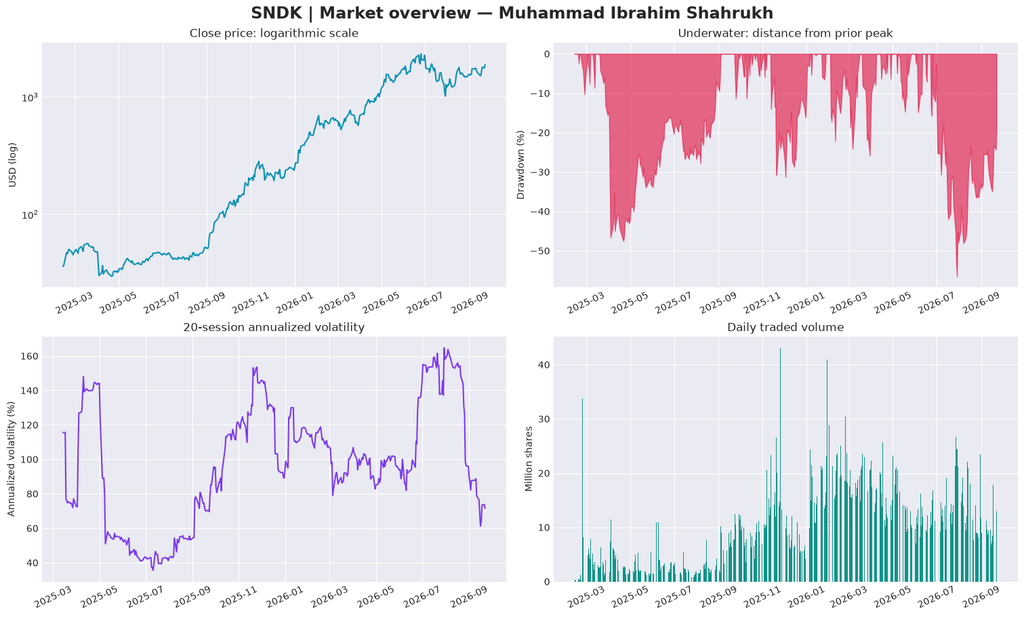

```python
fig,ax = plt.subplots(2,2,figsize=(15,9),constrained_layout=True)
ax[0,0].plot(eda.date,eda.close,color='#0891b2'); ax[0,0].set(title='Close price: logarithmic scale',ylabel='USD (log)'); ax[0,0].set_yscale('log')
ax[0,1].fill_between(eda.date,eda.drawdown_pct,color='#e11d48',alpha=.65); ax[0,1].set(title='Underwater: distance from prior peak',ylabel='Drawdown (%)')
ax[1,0].plot(eda.date,eda.volatility_20_pct,color='#7c3aed'); ax[1,0].set(title='20-session annualized volatility',ylabel='Annualized volatility (%)')
ax[1,1].bar(eda.date,eda.volume/1e6,color='#0d9488'); ax[1,1].set(title='Daily traded volume',ylabel='Million shares')
for a in ax.flat: a.tick_params(axis='x',rotation=25)
fig.suptitle('SNDK | Market overview — Muhammad Ibrahim Shahrukh',fontsize=17,fontweight='bold')
fig.savefig(OUT/'market_overview.png',dpi=150,bbox_inches='tight'); plt.show()
```

The logarithmic axis helps compare proportional moves across a large price range. Drawdown measures the drop from the highest close observed so far. Annualized volatility multiplies daily log-return standard deviation by √252; it is a descriptive convention, not a guaranteed forward risk estimate. The first 19/49 moving-average rows and first 20 volatility rows are intentionally missing. Close-price change is not dividend-reinvested total return.

## 04 · Returns, tails, calendar patterns & relationships

Ask whether apparent patterns survive the small sample and changing regime.

```python
regular = eda.loc[~eda.pre_regular_listing].copy()
# Recompute returns at the regular-listing boundary.
regular['daily_return_pct'] = regular.close.pct_change(fill_method=None)*100
regular['log_return'] = np.log(regular.close).diff()
r = regular.daily_return_pct.dropna()
display(pd.Series({'mean_daily_pct':r.mean(),'median_daily_pct':r.median(),'std_daily_pct':r.std(),
                   'skewness':r.skew(),'excess_kurtosis':r.kurt(),'positive_sessions_pct':100*r.gt(0).mean(),
                   'worst_day_pct':r.min(),'best_day_pct':r.max()}).to_frame('value'))
fig = make_subplots(rows=1,cols=2,subplot_titles=['Daily return distribution','Volume vs absolute return'])
fig.add_trace(go.Histogram(x=r,nbinsx=40,name='Return',marker_color='#22d3ee'),row=1,col=1)
fig.add_trace(go.Scatter(x=regular.volume/1e6,y=regular.daily_return_pct.abs(),mode='markers',
                         marker=dict(color=regular.date.astype('int64'),colorscale='Viridis',size=6),name='Session'),row=1,col=2)
fig.update_xaxes(title_text='Daily return (%)',row=1,col=1); fig.update_xaxes(title_text='Volume (million shares)',row=1,col=2)
fig.update_yaxes(title_text='Absolute daily return (%)',row=1,col=2)
show(fig,'Return tails & trading activity')
extremes=regular.loc[regular.daily_return_pct.abs().nlargest(10).index,['date','close','daily_return_pct','volume']]
display(extremes.sort_values('date'))
```

|  | value |
| --- | --- |
| mean_daily_pct | 1.140502 |
| median_daily_pct | 0.615726 |
| std_daily_pct | 6.561720 |
| skewness | 0.216349 |
| excess_kurtosis | 1.732151 |
| positive_sessions_pct | 55.555556 |
| worst_day_pct | -21.301615 |
| best_day_pct | 27.564953 |

[interactive chart not shown]

|  | date | close | daily_return_pct | volume |
| --- | --- | --- | --- | --- |
| 34 | 2025-04-03 | 38.259998 | -19.739879 | 7372000 |
| 35 | 2025-04-04 | 30.110001 | -21.301615 | 11428600 |
| 139 | 2025-09-04 | 62.500000 | 17.902286 | 10189000 |
| 156 | 2025-09-29 | 113.500000 | 16.865730 | 12435400 |
| 178 | 2025-10-29 | 204.360001 | 16.424544 | 9365000 |
| 194 | 2025-11-20 | 195.960007 | -20.328508 | 26590900 |
| 224 | 2026-01-06 | 349.630005 | 27.564953 | 24249700 |
| 309 | 2026-05-08 | 1562.339966 | 16.596019 | 20567600 |
| 341 | 2026-06-25 | 2335.000000 | 21.966510 | 15030200 |
| 365 | 2026-07-30 | 1279.959961 | 25.993950 | 24398700 |

```python
month_close = regular.set_index('date').close.resample('ME').last()
monthly = (month_close.pct_change(fill_method=None)*100).to_frame('return_pct').dropna()
monthly['year']=monthly.index.year; monthly['month']=monthly.index.month
heat=monthly.pivot(index='year',columns='month',values='return_pct').reindex(columns=range(1,13))
fig=px.imshow(heat,text_auto='.1f',color_continuous_scale='RdBu',color_continuous_midpoint=0,aspect='auto',labels={'color':'Return (%)'})
show(fig,'Month-end close returns (%) — final month may be partial',360)
regular['weekday']=regular.date.dt.day_name()
weekday_order=['Monday','Tuesday','Wednesday','Thursday','Friday']
show(px.box(regular,x='weekday',y='daily_return_pct',color='weekday',category_orders={'weekday':weekday_order},points='outliers'),
     'Weekday distributions: exploration, not a tested trading rule')
display(regular.groupby('weekday').daily_return_pct.agg(['count','mean','median','std']).reindex(weekday_order))
corrcols=['daily_return_pct','intraday_range_pct','overnight_gap_pct','volatility_20_pct','volume_ratio_20']
show(px.imshow(regular[corrcols].corr(method='spearman'),text_auto='.2f',zmin=-1,zmax=1,color_continuous_scale='RdBu',aspect='auto'),
     'Spearman correlation: contemporaneous descriptive relationships',560)
```

[interactive chart not shown]

| weekday | count | mean | median | std |
| --- | --- | --- | --- | --- |
| Monday | 76 | 1.663608 | 1.165972 | 5.933034 |
| Tuesday | 83 | 0.411897 | -0.181564 | 5.970216 |
| Wednesday | 82 | 1.473702 | 0.645566 | 5.533678 |
| Thursday | 78 | 0.743704 | 0.415503 | 8.179260 |
| Friday | 77 | 1.456682 | 1.800076 | 6.995057 |

[interactive chart not shown]

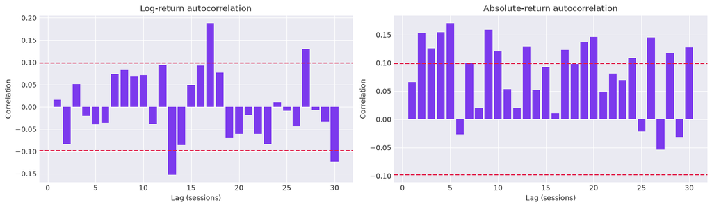

|  | series | adf_statistic | p_value | lags |
| --- | --- | --- | --- | --- |
| 0 | log_price | -0.290693 | 0.926812 | 17 |
| 1 | log_return | -3.079173 | 0.028133 | 17 |

**Interpretation guardrails**  
ADF has a unit-root null; a small p-value is evidence against that null, not proof of forecastability. Dashed ACF bounds are rough single-lag references, not multiple-testing-adjusted significance. Short history and regime shifts limit all seasonal conclusions.

```python
lags=np.arange(1,31)
fig,ax=plt.subplots(1,2,figsize=(14,4),constrained_layout=True)
for a,series,title in [(ax[0],regular.log_return.dropna(),'Log-return autocorrelation'),(ax[1],regular.log_return.dropna().abs(),'Absolute-return autocorrelation')]:
    a.bar(lags,[series.autocorr(int(k)) for k in lags],color='#7c3aed')
    band=1.96/np.sqrt(len(series)); a.axhline(band,color='#e11d48',ls='--'); a.axhline(-band,color='#e11d48',ls='--')
    a.set(title=title,xlabel='Lag (sessions)',ylabel='Correlation')
plt.show()
adf=[]
for name,values in [('log_price',np.log(regular.close)),('log_return',regular.log_return.dropna())]:
    result=adfuller(values,autolag='AIC')
    adf.append({'series':name,'adf_statistic':result[0],'p_value':result[1],'lags':result[2]})
display(pd.DataFrame(adf))
card('Interpretation guardrails','ADF has a unit-root null; a small p-value is evidence against that null, not proof of forecastability. Dashed ACF bounds are rough single-lag references, not multiple-testing-adjusted significance. Short history and regime shifts limit all seasonal conclusions.','#db2777')
```

## 05 · Forecast design: simulate the real task

Freeze each forecast origin; predict the entire horizon without seeing intermediate future closes.

We model **next-session log returns** using the last 21 known returns. Features contain five most-recent returns, trailing mean/std over 5/10/21 sessions and trailing sums over 5/21 sessions. At inference, predicted returns feed back into the features. This avoids requiring future volume, high or low prices.

**Evaluation protocol (fixed before model selection)**

- Forecast to 2026-12-31 from the last supplied observation. The horizon excludes weekends and scheduled exchange holidays; early closes count as sessions.
- Reserve the final full-horizon historical block as an untouched test period.
- Before it, use three non-overlapping validation blocks of the same horizon, with expanding training history.
- Compare random walk, 63-session log drift, standardized Ridge, Random Forest, Extra Trees, histogram gradient boosting, XGBoost and CatBoost. Hyperparameters are fixed, deliberately modest for this sample size.
- Select the lowest **mean origin-normalized RMSE** across the three validation origins. This scales each fold by its origin price and prevents high-price folds dominating selection.
- Score every candidate on the held-out block for transparency, but do not use those results to change the selected model. Refit the selected model on all available regular-listing observations for the final projection.

No random split, no full-data scaling, no centered rolling windows, and no future realized OHLCV inputs. A simple baseline is allowed to win. This is the best **tested candidate under this protocol**, not a claim about all possible models.

```python
model_df = df.loc[df.date.ge('2025-02-24')].reset_index(drop=True)
prices=model_df.close.to_numpy(float)
dates=model_df.date
future_dates=sessions(df.date.max()+pd.Timedelta(days=1),'2026-12-31')
H=len(future_dates); N=len(prices); test_origin=N-H
cv_origins=[test_origin-3*H,test_origin-2*H,test_origin-H]
assert cv_origins[0] > 100
splits=[]
for label,o in [(f'CV {i+1}',o) for i,o in enumerate(cv_origins)]+[('Test',test_origin)]:
    splits.append({'split':label,'train_rows':o,'train_end':str(dates.iloc[o-1].date()),
                   'forecast_start':str(dates.iloc[o].date()),'forecast_end':str(dates.iloc[o+H-1].date()),'horizon':H})
split_table=pd.DataFrame(splits); display(split_table)
split_table.to_csv(OUT/'evaluation_splits.csv',index=False)
print(f'Future forecast: {future_dates[0].date()} to {future_dates[-1].date()}, {H} scheduled sessions.')

FEATURE_NAMES=[f'return_lag_{i}' for i in range(1,6)]+[f'{stat}_{w}' for w in [5,10,21] for stat in ['mean','std']]+['sum_5','sum_21']
def features(history):
    r=np.asarray(history)
    assert len(r)>=21
    return np.array(list(r[-5:][::-1])+[v for w in [5,10,21] for v in [r[-w:].mean(),r[-w:].std(ddof=1)]]+[r[-5:].sum(),r[-21:].sum()])

def supervised(p):
    r=np.diff(np.log(p))
    X=np.vstack([features(r[:i]) for i in range(21,len(r))])
    y=r[21:]
    return X,y

FACTORIES={
 'Ridge':lambda:make_pipeline(StandardScaler(),Ridge(alpha=10)),
 'Random Forest':lambda:RandomForestRegressor(n_estimators=200,max_depth=4,min_samples_leaf=10,random_state=SEED,n_jobs=1),
 'Extra Trees':lambda:ExtraTreesRegressor(n_estimators=200,max_depth=4,min_samples_leaf=10,random_state=SEED,n_jobs=1),
 'Hist Gradient Boosting':lambda:HistGradientBoostingRegressor(max_iter=120,max_leaf_nodes=7,l2_regularization=10,learning_rate=.04,early_stopping=False,random_state=SEED),
 'XGBoost':lambda:XGBRegressor(n_estimators=150,max_depth=2,learning_rate=.035,min_child_weight=10,reg_lambda=10,subsample=1,colsample_bytree=1,objective='reg:squarederror',random_state=SEED,n_jobs=1),
 'CatBoost':lambda:CatBoostRegressor(iterations=150,depth=3,learning_rate=.035,l2_leaf_reg=10,loss_function='RMSE',random_seed=SEED,verbose=False,allow_writing_files=False,thread_count=1)
}
MODELS=['Random walk','Log drift (63)']+list(FACTORIES)
def forecast(name,p,h,return_model=False):
    hist=list(np.diff(np.log(p))); fitted=None
    if name=='Random walk': pred=np.repeat(p[-1],h)
    elif name=='Log drift (63)': pred=p[-1]*np.exp(np.arange(1,h+1)*np.mean(hist[-63:]))
    else:
        X,y=supervised(p); fitted=FACTORIES[name](); fitted.fit(X,y)
        predicted=[]
        for _ in range(h):
            z=float(fitted.predict(features(hist).reshape(1,-1))[0])
            hist.append(z); predicted.append(z)
        pred=p[-1]*np.exp(np.cumsum(predicted))
    assert np.isfinite(pred).all() and (pred>0).all()
    return (pred,fitted) if return_model else pred

def metrics(actual,pred,train):
    rmse=np.sqrt(mean_squared_error(actual,pred))
    baseline=np.repeat(train[-1],len(actual))
    scale=np.mean(np.abs(np.diff(train)))
    # Direction is cumulative relative to origin, not a daily trading hit rate.
    direction=np.mean(np.sign(actual-train[-1])==np.sign(pred-train[-1]))*100
    return {'MAE_USD':mean_absolute_error(actual,pred),'RMSE_USD':rmse,
            'NRMSE_origin_pct':100*rmse/train[-1], 'MAPE_pct':100*np.mean(np.abs((actual-pred)/actual)),
            'sMAPE_pct':200*np.mean(np.abs(actual-pred)/(np.abs(actual)+np.abs(pred))),
            'MASE':mean_absolute_error(actual,pred)/scale,'R2':r2_score(actual,pred),
            'RMSE_skill_vs_random_walk':1-rmse/np.sqrt(mean_squared_error(actual,baseline)),
            'origin_direction_accuracy_pct':direction}

cv_rows=[]; cv_paths=[]
for fold,o in enumerate(cv_origins,1):
    for name in MODELS:
        pred=forecast(name,prices[:o],H)
        cv_rows.append({'fold':fold,'model':name,**metrics(prices[o:o+H],pred,prices[:o])})
        for h,(actual,predicted) in enumerate(zip(prices[o:o+H],pred),1):
            cv_paths.append({'fold':fold,'model':name,'horizon':h,'actual':actual,'predicted':predicted,'origin_price':prices[o-1]})
cv=pd.DataFrame(cv_rows)
leaderboard=cv.groupby('model').agg(mean_cv_nrmse_pct=('NRMSE_origin_pct','mean'),sd_cv_nrmse_pct=('NRMSE_origin_pct','std'),mean_cv_mape_pct=('MAPE_pct','mean')).sort_values('mean_cv_nrmse_pct')
WINNER=leaderboard.index[0]  # Locked before reading test outcomes.
display(leaderboard.style.background_gradient(cmap='YlGnBu'))
card('Validation-selected model',f'{WINNER}. Selection is based only on the three earlier validation blocks.')
cv.to_csv(OUT/'validation_metrics.csv',index=False); leaderboard.to_csv(OUT/'model_leaderboard.csv')
pd.DataFrame(cv_paths).to_csv(OUT/'validation_predictions.csv',index=False)
show(px.bar(leaderboard.reset_index(),x='model',y='mean_cv_nrmse_pct',error_y='sd_cv_nrmse_pct',color='model'),
     'Validation error: lower is better; bars show variation across origins')
```

```
Future forecast: 2026-09-23 to 2026-12-31, 70 scheduled sessions.
```

|  | split | train_rows | train_end | forecast_start | forecast_end | horizon |
| --- | --- | --- | --- | --- | --- | --- |
| 0 | CV 1 | 117 | 2025-08-11 | 2025-08-12 | 2025-11-18 | 70 |
| 1 | CV 2 | 187 | 2025-11-18 | 2025-11-19 | 2026-03-03 | 70 |
| 2 | CV 3 | 257 | 2026-03-03 | 2026-03-04 | 2026-06-11 | 70 |
| 3 | Test | 327 | 2026-06-11 | 2026-06-12 | 2026-09-22 | 70 |

| model | mean_cv_nrmse_pct | sd_cv_nrmse_pct | mean_cv_mape_pct |
| --- | --- | --- | --- |
| CatBoost | 134.031304 | 91.218913 | 38.908054 |
| Extra Trees | 134.246912 | 108.366860 | 40.860452 |
| Log drift (63) | 146.216535 | 105.892711 | 46.905311 |
| Random Forest | 147.807453 | 94.889121 | 43.398331 |
| Ridge | 149.059021 | 76.203477 | 41.898815 |
| Hist Gradient Boosting | 150.293085 | 100.556062 | 48.665860 |
| Random walk | 152.899859 | 82.055572 | 42.313577 |
| XGBoost | 154.260853 | 96.188554 | 47.846545 |

**Validation-selected model**  
CatBoost. Selection is based only on the three earlier validation blocks.

[interactive chart not shown]

## 06 · Untouched test: results & diagnostics

Report misses as clearly as successes.

```python
test_rows=[]; test_predictions={}
train=prices[:test_origin]; actual=prices[test_origin:]
for name in MODELS:
    pred=forecast(name,train,H)
    test_predictions[name]=pred
    test_rows.append({'model':name,'selected_on_validation':name==WINNER,**metrics(actual,pred,train)})
test=pd.DataFrame(test_rows).set_index('model')
display(test.style.format(precision=3).background_gradient(subset=['RMSE_USD','MAPE_pct'],cmap='YlOrRd'))
test.to_csv(OUT/'test_metrics.csv')
test_export=pd.DataFrame({'date':dates.iloc[test_origin:].to_numpy(),'actual_close':actual,**test_predictions})
test_export.to_csv(OUT/'test_predictions.csv',index=False)
fig=go.Figure(go.Scatter(x=dates.iloc[test_origin:],y=actual,name='Observed',line=dict(color='white',width=3)))
for name in MODELS:
    fig.add_trace(go.Scatter(x=dates.iloc[test_origin:],y=test_predictions[name],name=name,visible=True if name in [WINNER,'Random walk'] else 'legendonly'))
show(fig,'Frozen-origin test forecasts — click legend to compare all models',600)
selected=test.loc[WINNER]
card('Did the selected model beat the baseline?',
     f"Test RMSE ${selected.RMSE_USD:,.2f}; MAPE {selected.MAPE_pct:.2f}%; RMSE skill {selected.RMSE_skill_vs_random_walk:.3f}. Positive skill beats the frozen-price baseline; negative skill loses.", '#d97706')
```

| model | selected_on_validation | MAE_USD | RMSE_USD | NRMSE_origin_pct | MAPE_pct | sMAPE_pct | MASE | R2 | RMSE_skill_vs_random_walk | origin_direction_accuracy_pct |
| --- | --- | --- | --- | --- | --- | --- | --- | --- | --- | --- |
| Random walk | False | 320.956 | 374.907 | 19.926 | 22.000 | 19.050 | 17.851 | -0.722 | 0.000 | 0.000 |
| Log drift (63) | False | 2129.477 | 2553.539 | 135.718 | 139.946 | 72.300 | 118.435 | -78.881 | -5.811 | 21.429 |
| Ridge | False | 823.253 | 920.676 | 48.933 | 55.398 | 40.803 | 45.787 | -9.384 | -1.456 | 21.429 |
| Random Forest | False | 921.128 | 1023.656 | 54.406 | 61.883 | 44.374 | 51.231 | -11.837 | -1.730 | 21.429 |
| Extra Trees | False | 1665.360 | 1906.137 | 101.309 | 110.704 | 64.579 | 92.623 | -43.511 | -4.084 | 21.429 |
| Hist Gradient Boosting | False | 2165.353 | 2569.859 | 136.585 | 142.281 | 73.469 | 120.431 | -79.906 | -5.855 | 20.000 |
| XGBoost | False | 1530.253 | 1790.069 | 95.140 | 101.218 | 60.686 | 85.108 | -38.255 | -3.775 | 20.000 |
| CatBoost | True | 928.648 | 1032.983 | 54.902 | 62.430 | 44.625 | 51.649 | -12.072 | -1.755 | 21.429 |

[interactive chart not shown]

**Did the selected model beat the baseline?**  
Test RMSE $1,032.98; MAPE 62.43%; RMSE skill -1.755. Positive skill beats the frozen-price baseline; negative skill loses.

**Reading the metrics.** MAE is average absolute error in dollars; RMSE penalizes large misses more; MAPE and sMAPE express relative error; MASE scales MAE by the training sample's average one-session absolute price change. MASE compares to a one-step scale, so use the explicit same-horizon random-walk skill for a fair forecast-baseline comparison. R² can be negative on unseen data. Direction accuracy here compares each horizon's change **from the forecast origin**, not profitable daily trades. One test path is a limited estimate, not proof of consistent superiority.

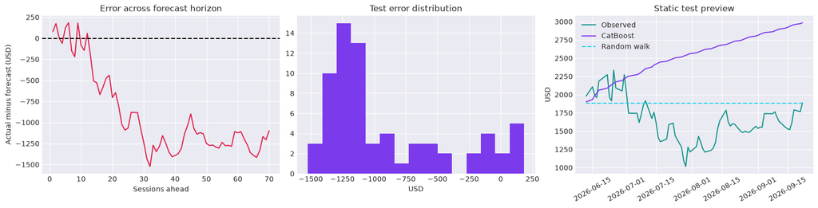

|  | sessions_ahead | actual | forecast | absolute_error | APE_pct |
| --- | --- | --- | --- | --- | --- |
| 0 | 1 | 1980.099976 | 1901.120264 | 78.979712 | 3.988673 |
| 1 | 5 | 2184.750000 | 2060.764094 | 123.985906 | 5.675062 |
| 2 | 21 | 1757.819946 | 2403.873323 | 646.053377 | 36.753103 |
| 3 | 42 | 1344.290039 | 2652.437821 | 1308.147782 | 97.311424 |
| 4 | 70 | 1887.040039 | 2985.510148 | 1098.470109 | 58.211277 |

```python
pred=test_predictions[WINNER]; errors=actual-pred
fig,ax=plt.subplots(1,3,figsize=(16,4),constrained_layout=True)
ax[0].plot(np.arange(1,H+1),errors,color='#e11d48'); ax[0].axhline(0,color='black',ls='--'); ax[0].set(title='Error across forecast horizon',xlabel='Sessions ahead',ylabel='Actual minus forecast (USD)')
ax[1].hist(errors,bins=15,color='#7c3aed'); ax[1].set(title='Test error distribution',xlabel='USD')
ax[2].plot(dates.iloc[test_origin:],actual,label='Observed',color='#0d9488'); ax[2].plot(dates.iloc[test_origin:],pred,label=WINNER,color='#7c3aed'); ax[2].plot(dates.iloc[test_origin:],test_predictions['Random walk'],label='Random walk',ls='--'); ax[2].legend(); ax[2].tick_params(axis='x',rotation=30); ax[2].set(title='Static test preview',ylabel='USD')
fig.savefig(OUT/'test_diagnostics.png',dpi=150,bbox_inches='tight'); plt.show()
horizon_rows=[]
for h in sorted(set([1,5,21,42,H])):
    if h<=H:
        horizon_rows.append({'sessions_ahead':h,'actual':actual[h-1],'forecast':pred[h-1],'absolute_error':abs(actual[h-1]-pred[h-1]),'APE_pct':100*abs(actual[h-1]-pred[h-1])/actual[h-1]})
display(pd.DataFrame(horizon_rows)); pd.DataFrame(horizon_rows).to_csv(OUT/'test_horizon_errors.csv',index=False)
```

## 07 · Explainability & sensitivity

Associations inside fitted models are not causal market drivers.

```python
# Explain a tree model without claiming it necessarily wins.
X_train,y_train=supervised(train)
rf=FACTORIES['Random Forest']().fit(X_train,y_train)
importance=pd.Series(rf.feature_importances_,index=FEATURE_NAMES).sort_values()
show(px.bar(x=importance.values,y=importance.index,orientation='h',labels={'x':'Impurity importance','y':'Feature'}),
     'Random Forest diagnostic — training-only feature importance')
card('Interpretability limitation','Impurity importance can be biased and is shared among correlated lag features. It describes this fitted Random Forest, not causal effects or out-of-sample predictive value.','#7c3aed')
# A source-boundary sensitivity check; this does not reselect the winner.
full_prices=df.close.to_numpy(float)
sensitivity_pred=forecast(WINNER,full_prices[:-H],H)
display(pd.DataFrame([{'training_basis':'Regular listing only',**metrics(actual,pred,train)},
                      {'training_basis':'Including six pre-listing rows',**metrics(actual,sensitivity_pred,full_prices[:-H])}]))
```

[interactive chart not shown]

**Interpretability limitation**  
Impurity importance can be biased and is shared among correlated lag features. It describes this fitted Random Forest, not causal effects or out-of-sample predictive value.

|  | training_basis | MAE_USD | RMSE_USD | NRMSE_origin_pct | MAPE_pct | sMAPE_pct | MASE | R2 | RMSE_skill_vs_random_walk | origin_direction_accuracy_pct |
| --- | --- | --- | --- | --- | --- | --- | --- | --- | --- | --- |
| 0 | Regular listing only | 928.647670 | 1032.982617 | 54.901787 | 62.429843 | 44.625287 | 51.648744 | -12.07214 | -1.755302 | 21.428571 |
| 1 | Including six pre-listing rows | 1113.213646 | 1248.500155 | 66.356286 | 74.541971 | 50.476803 | 62.855556 | -18.09580 | -2.330158 | 21.428571 |

## 08 · Remaining 2026: projection & uncertainty

Refit after evaluation; separate model paths from observed history.

**Uncertainty method.** Sample 5-session circular blocks from the most recent 126 historical log returns, after subtracting their sample mean. Add the cumulative sampled shocks to the selected model's log-price path. Use 5,000 paths and a fixed random seed. The 2.5/10/90/97.5 percentiles are **nominal simulated envelopes**, not calibrated confidence intervals or validated probabilities. They capture recent return variability and short blocks of dependence; they omit model/parameter uncertainty and can miss structural breaks. We also measure how often the same construction covers the held-out path, using training data only for those bands.

The no-change baseline and alternative candidate paths provide context. Daily forecasts start after the dataset's last date (September 22), even where dates have already elapsed at the time you read this notebook. They are snapshot-origin forecasts, not refreshed current predictions.

```
Test path coverage: nominal 80% envelope 51.4%; nominal 95% envelope 85.7%.
Coverage across one dependent path is descriptive; it does not establish calibration.
```

|  | date | ticker | forecast_origin | horizon_sessions | selected_model | forecast_close | sim_lower_80 | sim_upper_80 | sim_lower_95 | sim_upper_95 | random_walk_close |
| --- | --- | --- | --- | --- | --- | --- | --- | --- | --- | --- | --- |
| 0 | 2026-09-23 | SNDK | 2026-09-22 | 1 | CatBoost | 1922.803908 | 1752.779374 | 2115.590224 | 1666.861046 | 2224.399744 | 1887.040039 |
| 1 | 2026-09-24 | SNDK | 2026-09-22 | 2 | CatBoost | 1934.741557 | 1672.479357 | 2224.115901 | 1511.838241 | 2289.829577 | 1887.040039 |
| 2 | 2026-09-25 | SNDK | 2026-09-22 | 3 | CatBoost | 1962.131079 | 1650.628546 | 2269.560213 | 1470.364628 | 2458.000181 | 1887.040039 |
| 3 | 2026-09-28 | SNDK | 2026-09-22 | 4 | CatBoost | 1992.331121 | 1675.494330 | 2343.553897 | 1422.041392 | 2587.352307 | 1887.040039 |
| 4 | 2026-09-29 | SNDK | 2026-09-22 | 5 | CatBoost | 2005.808997 | 1630.992171 | 2394.436314 | 1441.347561 | 2563.941241 | 1887.040039 |

|  | date | forecast_close | sim_lower_80 | sim_upper_80 | random_walk_close |
| --- | --- | --- | --- | --- | --- |
| 5 | 2026-09-30 00:00:00 | 2,029.80 | 1,619.08 | 2,518.87 | 1,887.04 |
| 27 | 2026-10-30 00:00:00 | 2,500.62 | 1,529.75 | 3,959.70 | 1,887.04 |
| 47 | 2026-11-30 00:00:00 | 2,942.58 | 1,507.68 | 5,479.28 | 1,887.04 |
| 69 | 2026-12-31 00:00:00 | 3,518.95 | 1,601.99 | 7,408.87 | 1,887.04 |

[interactive chart not shown]

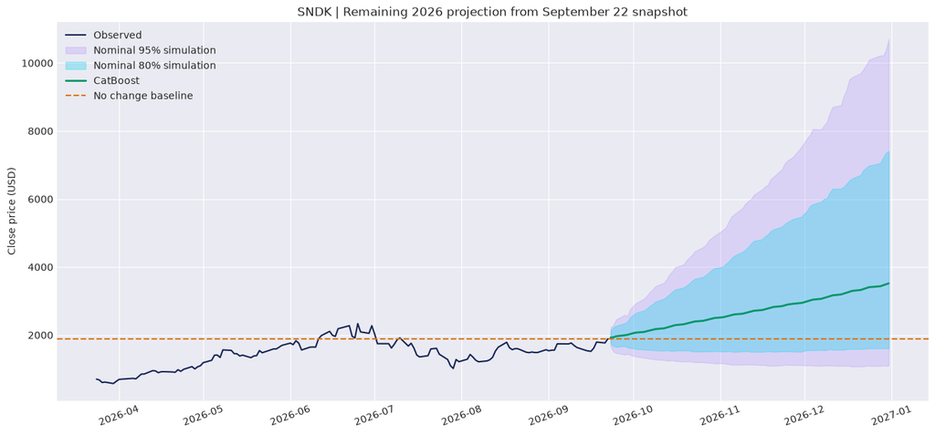

```python
def envelope(p,center,n_paths=5000,block=5,window=126):
    rng=np.random.default_rng(SEED)
    r=np.diff(np.log(p))[-window:]; r=r-r.mean()
    starts=rng.integers(0,len(r),size=(n_paths,int(np.ceil(len(center)/block))))
    idx=(starts[:,:,None]+np.arange(block))%len(r)
    shocks=r[idx].reshape(n_paths,-1)[:,:len(center)]
    sims=np.asarray(center)[None,:]*np.exp(np.cumsum(shocks,axis=1))
    return np.quantile(sims,[.025,.10,.90,.975],axis=0)

test_bands=envelope(train,pred)
coverage80=100*np.mean((actual>=test_bands[1])&(actual<=test_bands[2]))
coverage95=100*np.mean((actual>=test_bands[0])&(actual<=test_bands[3]))
print(f'Test path coverage: nominal 80% envelope {coverage80:.1f}%; nominal 95% envelope {coverage95:.1f}%.')
print('Coverage across one dependent path is descriptive; it does not establish calibration.')
final_path=forecast(WINNER,prices,H)
bands=envelope(prices,final_path)
future=pd.DataFrame({'date':future_dates,'ticker':'SNDK','forecast_origin':str(dates.iloc[-1].date()),'horizon_sessions':np.arange(1,H+1),
                     'selected_model':WINNER,'forecast_close':final_path,'sim_lower_80':bands[1],'sim_upper_80':bands[2],
                     'sim_lower_95':bands[0],'sim_upper_95':bands[3],'random_walk_close':prices[-1]})
assert (future.sim_lower_95<=future.sim_lower_80).all() and (future.sim_upper_80<=future.sim_upper_95).all()
assert future.date.is_unique and future.date.min()>df.date.max()
future.to_csv(OUT/'sndk_forecast_remaining_2026.csv',index=False,date_format='%Y-%m-%d')
alternative_paths=pd.DataFrame({'date':future_dates,**{name:forecast(name,prices,H) for name in MODELS}})
alternative_paths.to_csv(OUT/'alternative_model_forecasts.csv',index=False)
display(future.head())
month_end=future.groupby(future.date.dt.to_period('M')).tail(1)
display(month_end[['date','forecast_close','sim_lower_80','sim_upper_80','random_walk_close']].style.format({c:'{:,.2f}' for c in ['forecast_close','sim_lower_80','sim_upper_80','random_walk_close']}))

fig=go.Figure()
fig.add_trace(go.Scatter(x=dates.iloc[-126:],y=prices[-126:],name='Observed close',line=dict(color='white',width=2)))
for low,high,label,color in [(bands[0],bands[3],'Nominal 95% simulation','rgba(167,139,250,0.15)'),(bands[1],bands[2],'Nominal 80% simulation','rgba(34,211,238,0.22)')]:
    fig.add_trace(go.Scatter(x=future_dates,y=high,line=dict(width=0),showlegend=False,hoverinfo='skip'))
    fig.add_trace(go.Scatter(x=future_dates,y=low,fill='tonexty',fillcolor=color,line=dict(width=0),name=label))
fig.add_trace(go.Scatter(x=future_dates,y=final_path,name=WINNER,line=dict(color='#34d399',width=3)))
fig.add_trace(go.Scatter(x=future_dates,y=np.repeat(prices[-1],H),name='No change baseline',line=dict(color='#fbbf24',dash='dash')))
show(fig,'2026 projection: model estimate with simulated uncertainty',660)

fig,ax=plt.subplots(figsize=(13,6),constrained_layout=True)
ax.plot(dates.iloc[-126:],prices[-126:],label='Observed',color='#172554')
ax.fill_between(future_dates,bands[0],bands[3],color='#a78bfa',alpha=.25,label='Nominal 95% simulation')
ax.fill_between(future_dates,bands[1],bands[2],color='#22d3ee',alpha=.35,label='Nominal 80% simulation')
ax.plot(future_dates,final_path,label=WINNER,color='#059669',lw=2)
ax.axhline(prices[-1],ls='--',color='#d97706',label='No change baseline')
ax.set(title='SNDK | Remaining 2026 projection from September 22 snapshot',ylabel='Close price (USD)'); ax.legend(); ax.tick_params(axis='x',rotation=20)
fig.savefig(OUT/'forecast_2026.png',dpi=150,bbox_inches='tight'); plt.show()
```

## 09 · Findings, limitations & responsible next steps

The conclusion is generated from the actual executed results.

```python
end=future.iloc[-1]
summary=f"""## Findings from this run

- **Data:** {len(df):,} rows, {df.date.min().date()} to {df.date.max().date()}; latest supplied close **${prices[-1]:,.2f}**. All numeric and OHLC structural checks passed. Prices were not independently authenticated.
- **Observed change:** {100*(last/first-1):,.1f}% from the first supplied close to the last, with maximum observed drawdown **{eda.drawdown_pct.min():.1f}%**. This unusual price range is retained as supplied; adjustment status is unknown.
- **Selection:** **{WINNER}** achieved the lowest mean validation origin-normalized RMSE ({leaderboard.iloc[0].mean_cv_nrmse_pct:.2f}%) among {len(MODELS)} fixed candidates.
- **Untouched {H}-session test:** MAE **${selected.MAE_USD:,.2f}**, RMSE **${selected.RMSE_USD:,.2f}**, MAPE **{selected.MAPE_pct:.2f}%**, R² **{selected.R2:.3f}**, random-walk RMSE skill **{selected.RMSE_skill_vs_random_walk:.3f}**. {'The selected candidate beat the baseline on this test path.' if selected.RMSE_skill_vs_random_walk>0 else 'The selected candidate did not beat the baseline on this test path; this materially weakens confidence in its projection.'}
- **December 31 point estimate:** **${end.forecast_close:,.2f}**, a model-implied change of **{100*(end.forecast_close/prices[-1]-1):.1f}%** from the snapshot close. This is a conditional model output, not a price target or expected investment return.
- **December 31 simulated envelopes:** nominal 80% **${end.sim_lower_80:,.2f}–${end.sim_upper_80:,.2f}**; nominal 95% **${end.sim_lower_95:,.2f}–${end.sim_upper_95:,.2f}**. Historical test path coverage was {coverage80:.1f}% and {coverage95:.1f}% respectively; these are not calibrated future probabilities.

## How to interpret the future projection

The selected model extends relationships estimated from a short and strongly changing historical sample. A rising or falling model path is evidence about that algorithm's extrapolation, not about future earnings, memory demand, valuation or market sentiment. Those inputs are absent here. The no-change baseline remains a useful reference, particularly when test performance is weak. Wide envelopes and disagreement between models express substantial uncertainty. They do not exclude more extreme outcomes.

## What this study cannot establish

This is one ticker, fewer than two years of observations, three validation origins and one untouched test path. Recursive errors accumulate; market regimes and corporate actions can invalidate learned relationships. Price-adjustment settings and exact collection parameters are unknown. Six pre-regular-listing rows are excluded from modeling and included only in the documented sensitivity check. Contemporary correlations and training feature importance do not imply causality. No trading backtest, transaction costs or profitable strategy is claimed.

## Next useful experiments

Verify source values and corporate actions; collect a longer comparable history; add causally available market/sector data; repeat rolling-origin evaluation across more regimes; evaluate direct multi-horizon models; calibrate intervals over many independent forecast origins. Preserve the original test result when designing follow-up experiments.
"""
display(Markdown(summary))
(OUT/'analysis_summary.md').write_text(summary)
run={'author':'Muhammad Ibrahim Shahrukh','snapshot_end':str(df.date.max().date()),'history_rows':len(df),'model_rows':len(model_df),'forecast_sessions':H,
     'selected_model':WINNER,'selection_metric':'mean validation RMSE / origin close * 100',
     'test_metrics':selected.drop('selected_on_validation').astype(float).to_dict(),
     'test_envelope_80_coverage_pct':coverage80,'test_envelope_95_coverage_pct':coverage95,
     'forecast_end':{k:(str(v.date()) if isinstance(v,pd.Timestamp) else v.item() if isinstance(v,np.generic) else v) for k,v in end.items()},'versions':versions,
     'clean_csv_sha256':hashlib.sha256(DATA_PATH.read_bytes()).hexdigest()}
(OUT/'run_summary.json').write_text(json.dumps(run,indent=2))
print('All analysis outputs saved to',OUT.resolve())
```

```
All analysis outputs saved to /workspace/scratch/214b76a18103/sndk-stock-forecast-2026/outputs
```

Findings from this run

- **Data:** 403 rows, 2025-02-13 to 2026-09-22; latest supplied close **$1,887.04**. All numeric and OHLC structural checks passed. Prices were not independently authenticated.

- **Observed change:** 5,141.8% from the first supplied close to the last, with maximum observed drawdown **-56.5%**. This unusual price range is retained as supplied; adjustment status is unknown.

- **Selection:** **CatBoost** achieved the lowest mean validation origin-normalized RMSE (134.03%) among 8 fixed candidates.

- **Untouched 70-session test:** MAE **$928.65**, RMSE **$1,032.98**, MAPE **62.43%**, R² **-12.072**, random-walk RMSE skill **-1.755**. The selected candidate did not beat the baseline on this test path; this materially weakens confidence in its projection.

- **December 31 point estimate:** **$3,518.95**, a model-implied change of **86.5%** from the snapshot close. This is a conditional model output, not a price target or expected investment return.

- **December 31 simulated envelopes:** nominal 80% **$1,601.99–$7,408.87**; nominal 95% **$1,097.68–$10,703.80**. Historical test path coverage was 51.4% and 85.7% respectively; these are not calibrated future probabilities.

How to interpret the future projection

The selected model extends relationships estimated from a short and strongly changing historical sample. A rising or falling model path is evidence about that algorithm's extrapolation, not about future earnings, memory demand, valuation or market sentiment. Those inputs are absent here. The no-change baseline remains a useful reference, particularly when test performance is weak. Wide envelopes and disagreement between models express substantial uncertainty. They do not exclude more extreme outcomes.

What this study cannot establish

This is one ticker, fewer than two years of observations, three validation origins and one untouched test path. Recursive errors accumulate; market regimes and corporate actions can invalidate learned relationships. Price-adjustment settings and exact collection parameters are unknown. Six pre-regular-listing rows are excluded from modeling and included only in the documented sensitivity check. Contemporary correlations and training feature importance do not imply causality. No trading backtest, transaction costs or profitable strategy is claimed.

Next useful experiments

Verify source values and corporate actions; collect a longer comparable history; add causally available market/sector data; repeat rolling-origin evaluation across more regimes; evaluate direct multi-horizon models; calibrate intervals over many independent forecast origins. Preserve the original test result when designing follow-up experiments.

## 10 · Sources, citation & reuse

Credit the market-data provider, collection tool and notebook author.

1. **Yahoo Finance — SNDK historical data:** https://finance.yahoo.com/quote/SNDK/history/ (source identified by the uploader; direct historical page could not be retrieved during preparation).
2. **yfinance documentation:** https://ranaroussi.github.io/yfinance/ — unofficial collection tool and data-use notice.
3. **Download parameter reference:** https://ranaroussi.github.io/yfinance/reference/api/yfinance.download.html — adjustment and action options; original settings remain unknown.
4. **Sandisk listing announcement, February 24, 2025:** https://investor.sandisk.com/news-releases/news-release-details/sandisk-celebrates-nasdaq-listing-after-completing-separation
5. **Nasdaq 2026 holiday schedule:** https://www.nasdaq.com/market-activity/stock-market-holiday-schedule
6. **NYSE calendar:** https://www.nyse.com/markets/hours-calendars
7. **scikit-learn chronological splitting:** https://scikit-learn.org/stable/modules/generated/sklearn.model_selection.TimeSeriesSplit.html — background; this notebook explicitly constructs horizon-matched folds.

Documentation consulted during preparation on **2026-09-24**; this is not the original data retrieval date.

**Suggested attribution:** Shahrukh, Muhammad Ibrahim. *SNDK Stock Data: EDA & 2026 Forecast*. Prepared 2026-09-24 from a user-supplied Yahoo Finance/yfinance snapshot ending 2026-09-22. Original collection settings and redistribution license unverified.

**Collection example for a future fresh snapshot (not a reconstruction of the original call):**

```
import yfinance as yf
fresh = yf.download('SNDK', start='2025-02-13', end='2026-09-23',
                    interval='1d', auto_adjust=False, actions=True,
                    repair=False, prepost=False)
fresh.to_csv('sndk_fresh_unadjusted_with_actions.csv')
```

Record the actual UTC retrieval time, `yf.__version__`, all arguments and adjustment basis. The end date is exclusive. Never silently mix this fresh sample with the supplied snapshot. Yahoo may revise historical values.